# Analysis & plots for paper: Seasonal habitat use and diel vertical migration in female spurdog in Nordic waters, Movement Ecology

Antonia Kloecker, IMR antonia.kloecker@hi.no

Version: 17 august, 2024

# 1 Read data

```r
# read in cleaned archival data
mdata <- readr::read_rds("data/spurdog/processed_data/archives-minutely-cleaned.rds")
hdata <- readr::read_rds("data/spurdog/processed_data/archive_hourly_DVM_wavelet.rds")
ddata <- readr::read_rds("data/spurdog/processed_data/archives-daily-cleaned.rds")
# Note: takes a couple of min to load 5 sec res data for all sharks
data <- readRDS("D:/development/SharksOnTheMove/PSAT/data/spurdog/processed_data/archives-full-cleaned.rds")
#data <- readRDS("D:/development/SharksOnTheMove/PSAT/data/spurdog/processed_data/archives-full-cleaned-5d.rds") # first five instead of 1 d removed

# wavelet specific output
wtavg <- readr::read_rds(file = "data/spurdog/processed_data/archive_hourly_depth_avgwavelet.rds")
wtc <- readr::read_rds(file = "data/spurdog/processed_data/archive_hourly_depth_compWave.rds")
wt <- readr::read_rds(file = "data/spurdog/processed_data/archive_hourly_nested_wavelet_depth_1_24_wodata.rds")
wtFS <- readr::read_rds(file = "data/spurdog/processed_data/archive_hourly_nested_wavelet_FS95cum_1_24_wodata.rds")
# store tag and shark id in a vector
tags <- list.files("data/spurdog/rawdata/")
sharks <- 1:length(tags)
```

CTD profiles station H2

```r
H2 <- read_table("data/spurdog/CTDstations/temp_H2_2019-2023.asc", na = "NaN") %>%
  pivot_longer(!Depth, names_to = "Date", values_to = "Temp") %>%
  mutate(Date = ymd(Date),
         Month = factor(lubridate::month(Date, label = T, abbr = F),
                 levels = c("November","December","January","February","March",
                            "April","May","June", "July", "August","September","October")),
         Year = year(Date)) %>%
  filter(Date >= min(ddata$Date) & Date <= max(ddata$Date)) %>%
  na.omit()
```

Add DVM covariate to minutely and daily data (so far only in hourly data - with which wavelet analysis was performed).

```r
# Daily data
t1 <- hdata %>%
      select(Date, DateTime, DVM, tagID) %>%
      # obtain the most frequent behaviour across each day
      group_by(tagID, Date, DVM) %>%
      summarise(c=n()) %>%
      filter(row_number(desc(c))==1) %>%
      ungroup() %>%
      select(tagID, Date, DVM)
ddata <- left_join(ddata, t1, by = c("tagID","Date"))

# Minutely data
t2 <- hdata %>% select(tagID, DateTime, DVM)
mdata <- left_join(mdata, t2, by = c("tagID","DateTime")) %>% fill(DVM, .direction = "downup")
```

# 2 Data coverage

Let’s get an overview of what the coverage of the data is. Not all tags remained on the shark for the same length of time. They were also deployed in different years.

```r
t <- ddata %>% group_by(sharkID) %>% summarise(n = n(), date_start = range(Date)[1], date_end = range(Date)[2])
t
```

```
#> # A tibble: 19 × 4
#>    sharkID     n date_start date_end
#>    <fct>   <int> <date>     <date>
#>  1 1         179 2019-11-28 2020-05-24
#>  2 2         179 2019-11-28 2020-05-24
#>  3 3         180 2019-11-27 2020-05-24
#>  4 4         180 2019-11-27 2020-05-24
#>  5 5         116 2019-11-27 2020-03-21
#>  6 6         222 2020-12-12 2021-07-21
#>  7 7         199 2020-12-09 2021-06-25
#>  8 8         169 2020-12-12 2021-05-29
#>  9 9         128 2020-12-13 2021-04-19
#> 10 10        214 2020-12-13 2021-07-14
#> 11 11        319 2021-11-05 2022-09-19
#> 12 12        360 2021-11-05 2022-10-30
#> 13 13         82 2021-11-05 2022-01-25
#> 14 14        360 2021-11-05 2022-10-30
#> 15 15        360 2021-11-05 2022-10-30
#> 16 16        273 2022-10-26 2023-07-25
#> 17 17        364 2022-10-26 2023-10-24
#> 18 18        364 2022-10-26 2023-10-24
#> 19 19        364 2022-10-26 2023-10-24
```

```r
mean(t$n)
```

```
#> [1] 242.7368
```

```r
sum(t$n)
```

```
#> [1] 4612
```

Overall, this dataset comprises cumulative 4612 days of timeseries data, with a mean of 242.7368421 days. Splitting that into quantiles looks like this:

```r
quantile(t$n,c(0,0.25,0.5,0.75,1))
```

```
#>   0%  25%  50%  75% 100%
#>   82  179  214  360  364
```

Let’s visualise this.

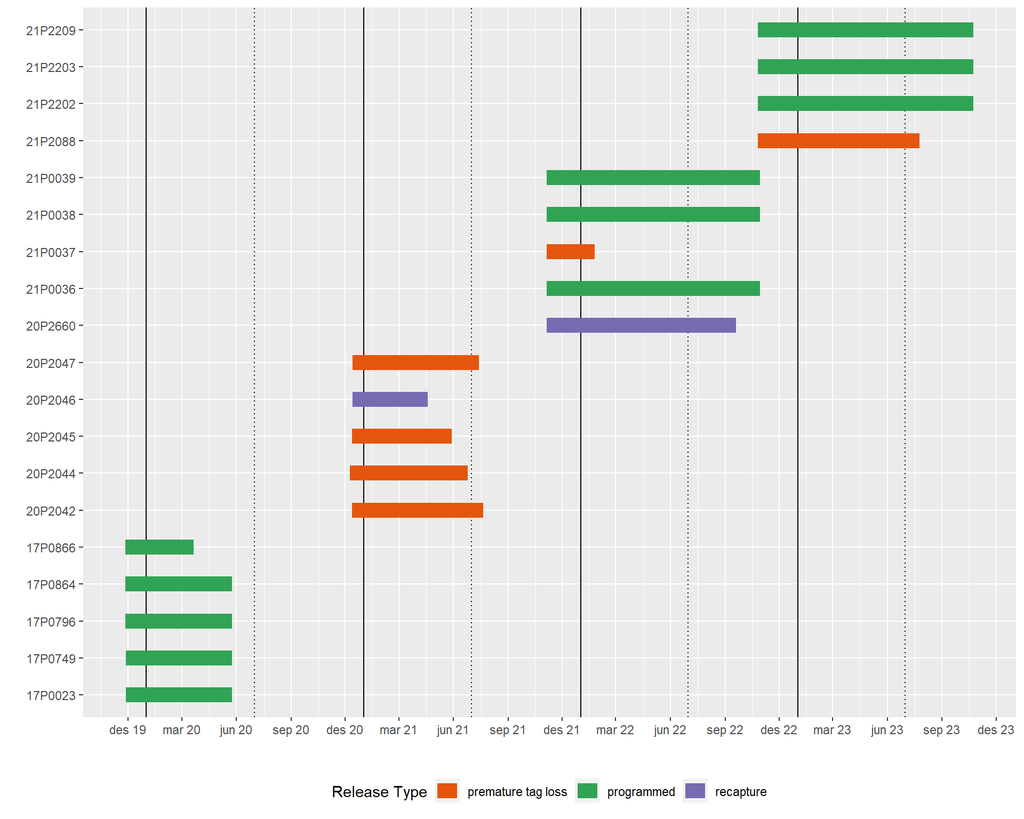

```r
ggplot(ddata %>% add_count(tagID) %>%
         mutate(release =
                  case_when(tagID %in% c("17P0023","17P0749","17P0796","17P0864","17P0866","21P0036","21P0038","21P0039","21P2202","21P2203","21P2209") ~ "programmed",
                            tagID %in% c("20P2046", "20P2660") ~ "recapture",
                            tagID %in% c("20P2042","20P2044","20P2045","20P2046", "20P2047","21P0037","21P2088") ~ "premature tag loss")
                ),
       )+
  geom_vline(xintercept = c(as.Date("2020-01-01"),as.Date("2021-01-01"),as.Date("2022-01-01"), as.Date("2023-01-01")), linetype='solid')+
  geom_vline(xintercept = c(as.Date("2020-07-01"),as.Date("2021-07-01"),as.Date("2022-07-01"),as.Date("2023-07-01")), linetype='dotted')+
  geom_line(aes(x = Date, y = tagID, col = release),linewidth = 5) +
  scale_colour_manual(values = c("#e6550d", "#31a354", "#756bb1"), name= "Release Type")+
  labs(y= "", x ="")+
  scale_x_date(date_breaks = "3 month",date_labels = "%b %y")+
  theme(legend.position = "bottom")+
  guides(fill=guide_legend(nrow=1,byrow=TRUE))
```

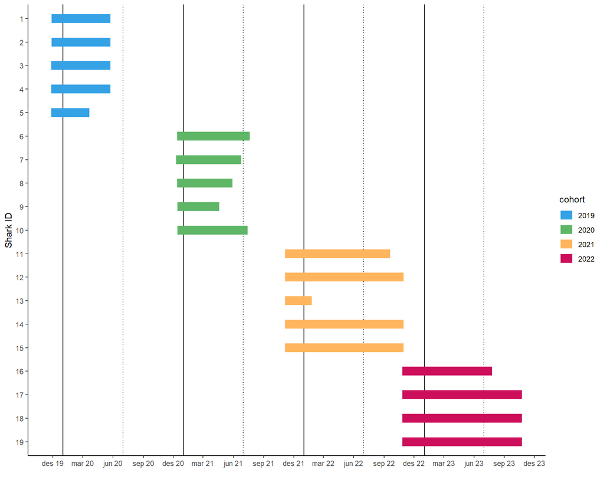

```r
#ddata %>% group_by(tagID) %>% count

# for poster
ggplot(ddata %>% add_count(tagID) %>% mutate(sharkID = fct_rev(sharkID)))+
  geom_vline(xintercept = c(as.Date("2020-01-01"),as.Date("2021-01-01"),as.Date("2022-01-01"), as.Date("2023-01-01")), linetype='solid')+
  geom_vline(xintercept = c(as.Date("2020-07-01"),as.Date("2021-07-01"),as.Date("2022-07-01"),as.Date("2023-07-01")), linetype='dotted')+
  geom_line(aes(x = Date, y = sharkID, col = cohort),linewidth = 5) +
  scale_colour_manual(values = c("#34a2e5ff","#5fb667ff", "#feb55dff","#cd0e5bff"), name= "cohort")+
  labs(y= "Shark ID", x ="")+
  scale_x_date(date_breaks = "3 month",date_labels = "%b %y")+
  theme(legend.position = "bottom")+
  guides(fill=guide_legend(nrow=1,byrow=TRUE))+
  theme_classic()
```

```r
ggsave(filename = "plots/spurdog/deployment_overview_poster.png", width = 9, height = 5)
```

# 3 Summary statisics

## 3.1 Overall

```r
# depth
quantile(data$Depth, probs = c(0,0.25,0.5,0.75,1)) # range, IQR,median
```

```
#>    0%   25%   50%   75%  100%
#>   0.0  21.5  56.5 128.0 644.0
```

```r
#quantile(mdata$Depth_median, probs = c(0,0.25,0.5,0.75,1)) # range, IQR,median
```

```r
# temp
round(quantile(data$Temperature, probs = c(0,0.25,0.5,0.75,1)),1)
```

```
#>   0%  25%  50%  75% 100%
#>  4.5  8.3  9.6 11.1 18.2
```

```r
#round(quantile(mdata$Temp_median, probs = c(0,0.25,0.5,0.75,1)),1) # range, IQR, median
```

### 3.1.1 TAD & TAT - weighted by reciprocal yday

Figure S4: Time-at-depth (A) and time-at-temperature (B) histograms for the entire deployment. Bars represent mean percentage of time (summarised by date) spent across individuals in each of the twelve depth and eight temperature bins. The means were weighted by the reciprocal of data points per Julian day to account for the heterogeneous temporal coverage due to different deployment lengths. Error bars indicate standard errors.

```r
# depth
TADd <- mdata %>%
      mutate(depth_bin = cut(Depth_median,breaks=c(0,10,25,50,75,100,150,200,300,400,500,600,700), include.lowest = T),
             yday = yday(Date)) %>%
      group_by(Date) %>%
      mutate(n_min = n()) %>%  # minutes available per date
      ungroup() %>%
      group_by(yday) %>%
      mutate(w_yday =1/n()) %>%
      ungroup() %>%
      group_by(Date, depth_bin, w_yday) %>% #not per sharkID - not interested in the interind. dif at this stage, no major differences
      reframe(TADperc = (n()/mean(n_min))*100) %>%  # count minutes in each bin per date and divide by available minutes per day
      # ensure that that non-occupied depth bins are zero (instead of absent)
      pivot_wider(names_from = depth_bin, values_from = TADperc) %>%
      replace(is.na(.), 0) %>%
      pivot_longer(!c(Date,w_yday), names_to = "depth_bin", values_to = "TADperc") %>%
      mutate(depth_bin = factor(depth_bin, levels = c("(600,700]","(500,600]","(400,500]","(300,400]",
                                                      "(200,300]","(150,200]","(100,150]","(75,100]",
                                                      "(50,75]","(25,50]","(10,25]","[0,10]"))) %>%
      # calculate mean and se per depth bin (aggregate over dates)
      group_by(depth_bin) %>%
      reframe(mean = weighted.mean(TADperc, w= w_yday),
              se = diagis::weighted_se(TADperc, w= w_yday))#sd(TADperc)/sqrt(n()))

p1 <- ggplot(data = TADd,
       aes(y = depth_bin, x=mean, xmin = mean-se, xmax = mean+se))+
  geom_bar(stat = "identity",  fill = "turquoise4", alpha = 0.5, colour = "grey10")+
  geom_errorbar(width = 0.2)+ # if error bar is missing - only one day per month
  #geom_hline(yintercept = c(11.5, 5.5), linetype = "dashed", colour = 'grey30', linewidth = 0.5)+ #"(200,250]"
  theme_bw()+
  labs(y = "Depth [m]", x = "Time [%]")

#first 75m
sum(TADd$mean[9:12])
```

```
#> [1] 68.97086
```

```r
# Time at epipelagic
sum(TADd$mean[6:12])
```

```
#> [1] 90.92763
```

```r
# Time at mesopelagic
sum(TADd$mean[1:5])
```

```
#> [1] 9.072371
```

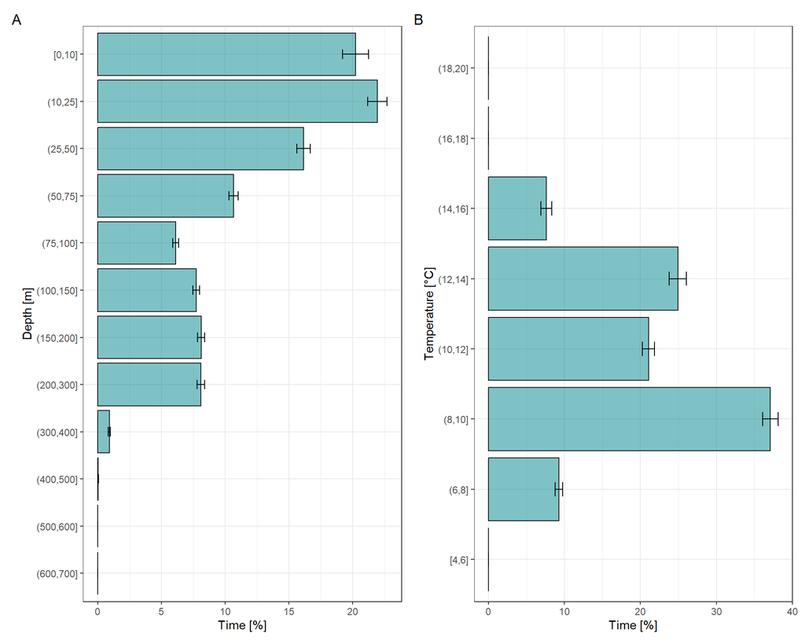

```r
#temp
TATd <- mdata %>%
      mutate(depth_bin = cut(Temp_median,breaks=seq(4,20,2), include.lowest = T),
             yday = yday(Date)) %>%
      group_by(Date) %>%
      mutate(n_min = n()) %>%  # minutes available per date
      ungroup() %>%
      group_by(yday) %>%
      mutate(w_yday =1/n()) %>%
      ungroup() %>%
      group_by(Date, depth_bin, w_yday) %>% #not per sharkID - not interested in the interind. dif at this stage, no major differences
      reframe(TADperc = (n()/mean(n_min))*100) %>%  # count minutes in each bin per date and divide by available minutes per day
      # ensure that that non-occupied depth bins are zero (instead of absent)
      pivot_wider(names_from = depth_bin, values_from = TADperc) %>%
      replace(is.na(.), 0) %>%
      pivot_longer(!c(Date,w_yday), names_to = "depth_bin", values_to = "TADperc") %>%
       mutate(depth_bin = factor(depth_bin, levels = c("[4,6]","(6,8]","(8,10]","(10,12]","(12,14]",
                                                      "(14,16]","(16,18]","(18,20]")))  %>%
      # calculate mean and se per depth bin (aggregate over dates)
      group_by(depth_bin) %>%
      reframe(mean = weighted.mean(TADperc, w= w_yday),
              se = diagis::weighted_se(TADperc, w= w_yday))#sd(TADperc)/sqrt(n()))

p2 <- ggplot(data = TATd,
       aes(y = depth_bin, x=mean, xmin = mean-se, xmax = mean+se))+
  geom_bar(stat = "identity", fill = "turquoise4", alpha = 0.5, colour = "grey10")+
  geom_errorbar(width = 0.2)+ # if error bar is missing - only one day per month
  theme_bw()+
  labs(y = "Temperature [\u00B0C]", x = "Time [%]")

p <- (p1|p2)+ plot_annotation(tag_levels = 'A')

p
```

```r
ggsave(p, filename = "plots/spurdog/supplement/fig4_TAD_TAT_weighted.png", width = 10, height = 7)


#8-10
TATd$mean[3]
```

```
#> [1] 37.1182
```

```r
TATd$se[3]
```

```
#> [1] 1.010672
```

```r
#10-12
TATd$mean[4]
```

```
#> [1] 21.07526
```

```r
TATd$se[4]
```

```
#> [1] 0.7977588
```

```r
#12-14
TATd$mean[5]
```

```
#> [1] 24.92403
```

```r
TATd$se[5]
```

```
#> [1] 1.11653
```

## 3.2 Per month

### 3.2.1 Boxplot

Figure S5: Average daily depth (A) and temperature (B) use across the different months of deployment based on 1-minute interval median depth and temperature values. Boxplots show the average median, boxes indicate the interquartile range (IQR – 25 and 75% quartiles) and whiskers extent to the average daily minimum and maximum depth and temperature per month.

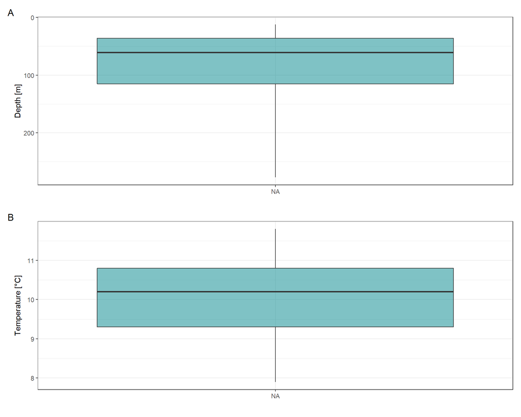

```r
# mean daily median, min and max depth/temp per month

md <- mdata %>%
      mutate(Month = factor(lubridate::month(Date, label = T, abbr = T),
                            levels = c("Nov","Dec","Jan","Feb","Mar","Apr","May","Jun", "Jul", "Aug","Sep","Oct"))) %>%
      group_by(Date, Month) %>%
      reframe(Dmin = min(Depth_median),# minimum per day across ind
              Dmax = max(Depth_median),# maximum per day across ind
              Dmed = median(Depth_median),
              D_lq = quantile(Depth_median, probs = c(0.25)),
              D_uq = quantile(Depth_median, probs = c(0.75)),
              Tmin = min(Temp_median),
              Tmed = median(Temp_median),
              Tmax = max(Temp_median),
              T_lq = quantile(Temp_median, probs = c(0.25)),
              T_uq = quantile(Temp_median, probs = c(0.75))) %>%
        ungroup() %>%
      group_by(Month) %>%
     reframe(n = n(),
             Dmin_mu = round(mean(Dmin),1),
              Dmin_sd = round(sd(Dmin),1),
              Dmin_se = round(sd(Dmin)/sqrt(n()),1),
              Dmed_mu = round(mean(Dmed),1),
              Dmed_sd = round(sd(Dmed),1),
              Dmed_se = round(sd(Dmed)/sqrt(n()),1),
              Dmax_mu = round(mean(Dmax),1),
              Dmax_se = round(sd(Dmax)/sqrt(n()),1),
              Dmax_sd = round(sd(Dmax),1),
              D_lq = round(mean(D_lq),1),
              D_uq = round(mean(D_uq),1),
              Tmin_mu = round(mean(Tmin),1),
              Tmin_se = round(sd(Tmin)/sqrt(n()),1),
              Tmin_sd = round(sd(Tmin),1),
              Tmed_mu = round(mean(Tmed),1),
              Tmed_se = round(sd(Tmed)/sqrt(n()),1),
              Tmed_sd = round(sd(Tmed),1),
              T_lq = round(mean(T_lq),1),
              T_uq = round(mean(T_uq),1),
              Tmax_mu = round(mean(Tmax),1),
              Tmax_sd = round(sd(Tmax),1),
              Tmax_se = round(sd(Tmax)/sqrt(n()),1))

p_depth <- ggplot(md, aes(x =Month))+
  geom_boxplot(aes(middle = Dmed_mu, upper = D_uq, lower = D_lq,
                   ymax = Dmax_mu, ymin = Dmin_mu), stat = "identity",
                fill = "turquoise4", alpha = 0.5)+
  labs(x = "", y = "Depth [m]")+
  scale_y_reverse()+
  theme_bw()

p_temp <- ggplot(md, aes(x =Month))+
  geom_boxplot(aes(middle = Tmed_mu, upper = T_uq, lower = T_lq,
                   ymax = Tmax_mu, ymin = Tmin_mu), stat = "identity", size = 0.5,
                fill = "turquoise4", alpha = 0.5)+
  labs(x = "", y = "Temperature [\u00B0C]")+
  theme_bw()

p <- (p_depth/p_temp)+ plot_annotation(tag_levels = 'A')
ggsave(p, filename = paste0("plots/spurdog/supplement/fig5_boxplot_DTuse.png"), width = 12, height = 15, units = "cm")
p
```

### 3.2.2 TAD

Figure S7: Time-at-depth histograms for each month of tag attachment. Bars represent mean percentage of time (summarised by date ) spent across individuals in each of the twelve defined depth ranges, with error bars indicating standard errors. Number of sharks contributing to each monthly plot are indicated.

```r
# TAD - monthly averages of daily distribution of time spent per depth bin per month, error bars mark standard error
TAD <- mdata %>%
      mutate(Month = factor(lubridate::month(Date, label = T, abbr = F),
                            levels = c("November","December","January","February",
                                       "March","April","May","June", "July",
                                       "August","September","October"))) %>%
      mutate(depth_bin = cut(Depth_median,breaks=c(0, 10,25,50,75,100,150,200,300,400,500,600,700), include.lowest = T)) %>%       group_by(Date) %>%
      mutate(n_min = n()) %>%  # minutes available per day
      ungroup() %>%
      group_by(Date, depth_bin, Month) %>% #sharkID - not per ind as we are not interested in the interind. dif at this stage, no major differences
      reframe(TADperc = (n()/mean(n_min))*100) %>%  # count minutes in each bin per day and divide by available minutes per day
      ungroup() %>%
      # ensure that that non-occupied depth bins are zero (instead of absent)
      pivot_wider(names_from = depth_bin, values_from = TADperc) %>%
      mutate(across(-Month, ~ replace_na(.,0))) %>%
      pivot_longer(!c(Date,Month), names_to = "depth_bin", values_to = "TADperc") %>%
      mutate(depth_bin = factor(depth_bin, levels = c("(600,700]","(500,600]","(400,500]","(300,400]",
                                                      "(200,300]","(150,200]","(100,150]","(75,100]",
                                                      "(50,75]","(25,50]","(10,25]","[0,10]"))) %>%
      # calculate mean and se per depth bin (aggregate over dates)
      group_by(Month, depth_bin) %>%
      reframe(mean = mean(TADperc),
              se = sd(TADperc)/sqrt(n())) # standard error, if there is only one value will return NA


TAD2 <- mdata %>%
      mutate(Month = factor(lubridate::month(Date, label = T, abbr = F),
                            levels = c("November","December","January","February",
                                       "March","April","May","June", "July",
                                       "August","September","October"))) %>%
      mutate(depth_bin = cut(Depth_median,breaks=c(0,10,200,700), include.lowest = T)) %>%
      mutate(depth_bin = fct_rev(depth_bin)) %>%
      group_by(Date) %>%
      mutate(n_min = n()) %>%  # minutes available per day
      ungroup() %>%
      group_by(Date, depth_bin, Month) %>% #sharkID - not per ind as we are not interested in the interind. dif at this stage, no major differences
      reframe(TADperc = (n()/mean(n_min))*100) %>%  # count minutes in each bin per day and divide by available minutes per day
      ungroup() %>%
      # ensure that that non-occupied depth bins are zero (instead of absent)
      pivot_wider(names_from = depth_bin, values_from = TADperc) %>%
      mutate(across(-Month, ~ replace_na(.,0))) %>%
      pivot_longer(!c(Date,Month), names_to = "depth_bin", values_to = "TADperc") %>%
            # calculate mean and se per depth bin (aggregate over dates)
      group_by(Month, depth_bin) %>%
      reframe(mean = mean(TADperc),
              se = sd(TADperc)/sqrt(n())) # standard error, if there is only one value will return NA
TAD2 %>% filter(depth_bin == "(200,700]")
```

```
#> # A tibble: 1 × 4
#>   Month depth_bin  mean    se
#>   <ord> <chr>     <dbl> <dbl>
#> 1 <NA>  (200,700]  11.4 0.358
```

```r
TAD2 %>% filter(depth_bin == "[0,10]")
```

```
#> # A tibble: 1 × 4
#>   Month depth_bin  mean    se
#>   <ord> <chr>     <dbl> <dbl>
#> 1 <NA>  [0,10]     14.5 0.758
```

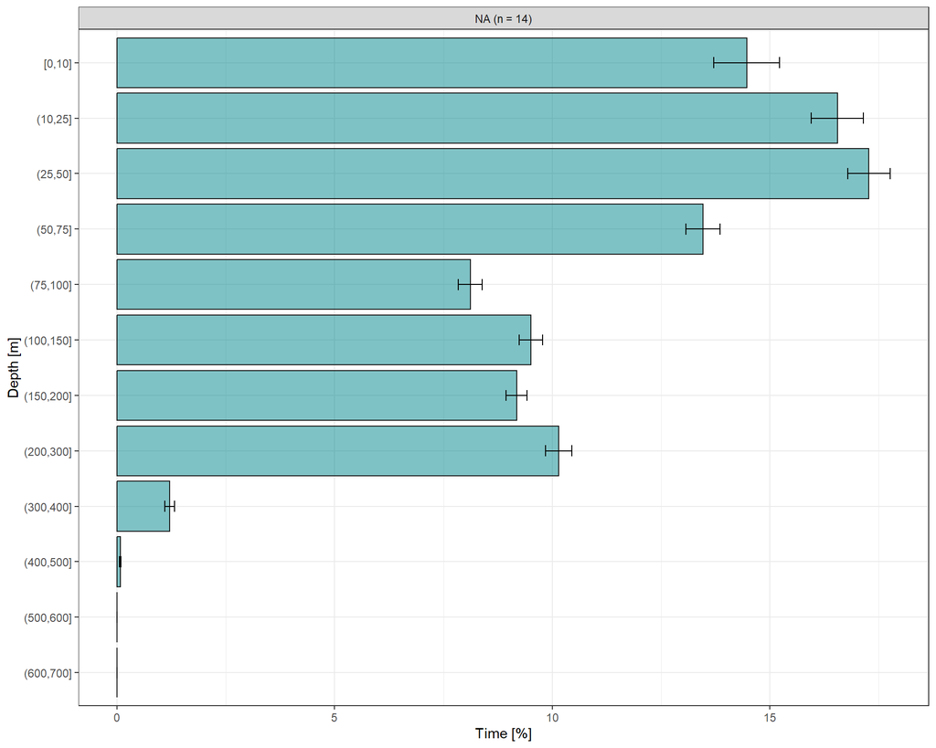

```r
n <- ddata %>% mutate(Month = factor(month(Date), levels = c(11:12,1:10))) %>% group_by(Month) %>% reframe(n = length(unique(sharkID)))

ggplot(data = TAD,
       aes(y = depth_bin, x=mean, xmin = mean-se, xmax = mean+se))+
  geom_bar(stat = "identity", fill = "turquoise4", alpha = 0.5, colour = "grey10")+
  geom_errorbar(width = 0.2)+ # if error bar is missing - only one day per month
  facet_wrap(~Month, labeller = stickylabeller::label_glue('{Month} (n = {n$n})'))+
  #geom_hline(yintercept = c(11.5, 5.5), linetype = "dashed", colour = 'grey30', linewidth = 0.5)+ #"(200,250]"
  theme_bw()+
  labs(y = "Depth [m]", x = "Time [%]")
```

```r
ggsave(filename = "plots/spurdog/supplement/fig7_TAD_monthly.png", width = 12, height = 14)
```

### 3.2.3 TAT

Figure S8: Time-at-temperature histograms for each month of tag attachment. Bars represent mean percentage of time (summarised by date) spent across individuals in each of the eight defined temperature ranges, with error bars indicating standard errors. Number of sharks contributing to each monthly plot are indicated.

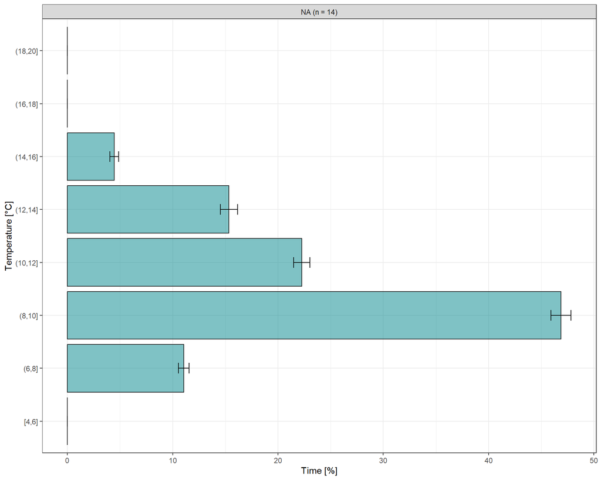

```r
# TAT - monthly averages of daily distribution of time spent per temp bin per month, error bars mark standard error
TAT <- mdata %>%
      mutate(Month = factor(lubridate::month(Date, label = T, abbr = F),
                            levels = c("November","December","January","February",
                                       "March","April","May","June", "July",
                                       "August","September","October"))) %>%
      mutate(temp_bin = cut(Temp_median,breaks=seq(4,20,2), include.lowest = T)) %>%
      group_by(Date) %>%
      mutate(n_min = n()) %>%  # minutes available per day
      ungroup() %>%
      group_by(Date, temp_bin, Month) %>% #sharkID - not per ind as we are not interested in the interind. dif at this stage, no major differences (just in july- more time at 6-8°C)
      reframe(TATperc = (n()/mean(n_min))*100) %>%  # count minutes in each bin per day and divide by available minutes per day
      ungroup() %>%
      # ensure that that non-occupied depth bins are zero (instead of absent)
      pivot_wider(names_from = temp_bin, values_from = TATperc) %>%
      mutate(across(-Month, ~ replace_na(.,0))) %>%
      pivot_longer(!c(Date,Month), names_to = "temp_bin", values_to = "TATperc") %>%
      mutate(temp_bin = factor(temp_bin, levels = c("[4,6]","(6,8]","(8,10]","(10,12]","(12,14]",
                                                      "(14,16]","(16,18]","(18,20]"))) %>%
      # calculate mean and se per depth bin (aggregate over dates)
      group_by(Month, temp_bin) %>%  # mean and se per month based on daily summaries
      reframe(mean = mean(TATperc),
              se = sd(TATperc)/sqrt(n())) # standard error, if there is only one value will return NA

ggplot(data = TAT,
       aes(y = temp_bin, x=mean, xmin = mean-se, xmax = mean+se))+
  geom_bar(stat = "identity",  fill = "turquoise4", alpha = 0.5, colour = "grey10")+
  geom_errorbar(width = 0.2)+ # if error bar is missing - only one day per month
  facet_wrap(~Month, labeller = stickylabeller::label_glue('{Month} (n = {n$n})'))+
  theme_bw()+
  labs(y = "Temperature [\u00B0C]", x = "Time [%]")
```

```r
ggsave(filename = "plots/spurdog/supplement/fig5_TAT_monthly.png", width = 12, height = 8)
```

# 4 Realised vs. available DT niche

## 4.1 Overall - Weighted by yday

Figure 1: Depth-temperature niche for 19 female spurdogs. Red colours denote the density of hourly data points (n=110,360) within a given grid cell weighted by the reciprocal of data points per Julian day. Black dotted and solid lines indicate the niche space that encompasses 50% and 95% of the points respectively. Marginal densities are shown for both covariates on the upper and right hand side. For visualisation purposes, the y-axis was limited to 400m depth.

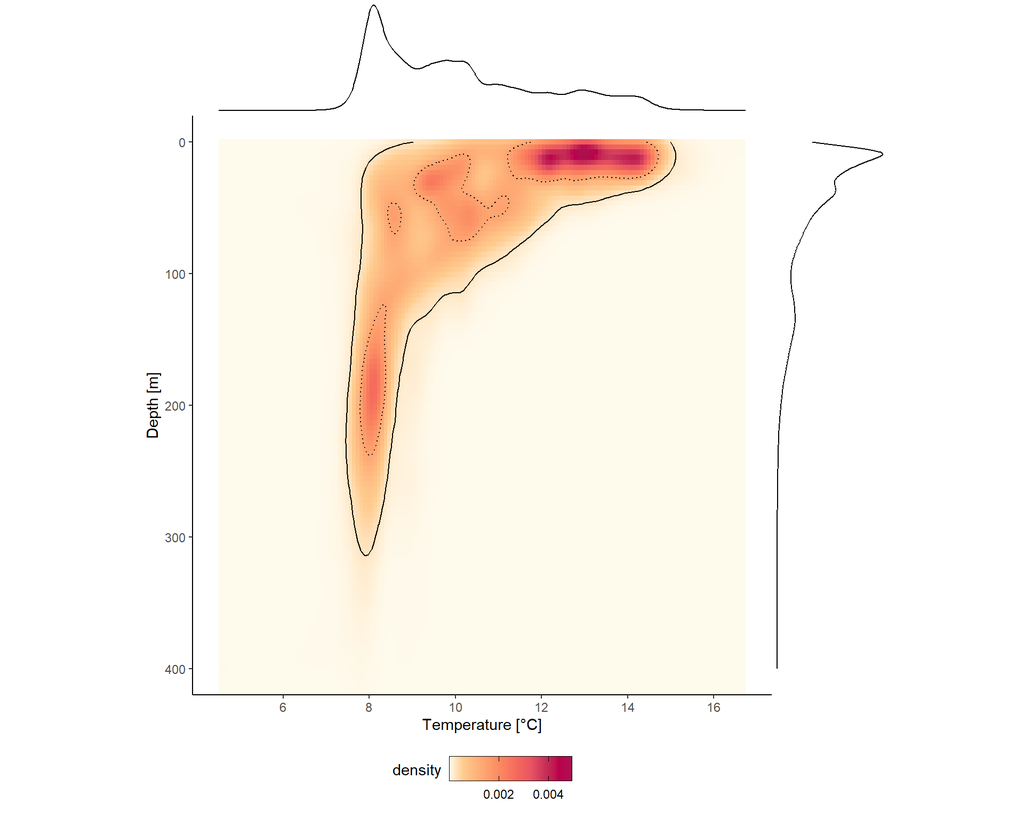

```r
## Weights for track data: Ensures weighting of points per yday for shark data.
# calculate weights as reciprocal sum of entries per julian day
hdata_w <- hdata %>% mutate(yday = yday(Date)) %>% group_by(yday) %>% mutate(weights = 1/n()) %>% ungroup()
dens <- kde2d.weighted(hdata_w$Depth_median, hdata_w$Temp_median, hdata_w$weights, n = 150)
dfdens <- data.frame(expand.grid(x=dens$x, y=dens$y), z=as.vector(dens$z))

## PLOT
# over all months
p2 <- ggplot() +
   geom_point(data = hdata_w, aes(y = Temp_median, x = Depth_median), colour = "white")+
   geom_tile(data = dfdens, aes(y = y, x = x, fill = z))+#after_stat(density)

  # 50% contour line
  geom_contour(data = dfdens,aes(x=x, y=y, z=z), colour = "black", lty = "dotted",
    breaks = density_quantiles_w(x = hdata_w$Depth_median, y = hdata_w$Temp_median, w = hdata_w$weights, quantiles = c(0.5))) +
  # 95% contour line
  geom_contour(data = dfdens, aes(x=x, y=y, z=z), colour = "black", lty = "solid",
    breaks = density_quantiles_w(x = hdata_w$Depth_median, y = hdata_w$Temp_median, w = hdata_w$weights, quantiles = c(0.95))) +

  scale_x_reverse()+
  scale_y_continuous(breaks=seq(6,18,2), labels=seq(6,18,2))+
  scale_fill_gradientn("density", colors = c("#fefaecff","#FECC8FFF",
                                             "#FEB37BFF","#FD9A6AFF","#FA815FFF","#F4685CFF",
                                             "#E85362FF","#c83158ff","#bc004cff","#ab114fff"),
                       guide = guide_colorbar(frame.colour = "black", ticks.colour = "black", title.vjust=0.8),
                       breaks = c(0.002,0.004), labels = c(0.002,0.004))+
  labs(x = "Depth [m]", y = "Temperature [\u00B0C]")+
  coord_flip(xlim = c(400,0))+
  theme_classic()+
  theme(aspect.ratio = 1, legend.position = "bottom", legend.box = "horizontal",
        legend.direction = "horizontal")

p3 <- ggExtra::ggMarginal(p2, type = "density") # if expand c(0,0) above marginal densities do not match - open issue
p3
```

```r
ggsave(plot = p3, filename = "plots/spurdog/paper/fig1_DTniche.png", width = 15, height = 15, units = "cm")
```

## 4.2 By month w station profiles

Figure S6: Realised depth-temperature niche by female spurdogs in the context of available habitat for each month. Number of sharks contributing to each monthly plot are indicated. Red colours denote the density of hourly datapoints within a given grid cell. Black dotted and solid lines indicate the niche space that encompasses 50% and 95% of these data, respectively. The profiles in blue are CTD profiles from the hydrographic station H2 in Hardangerfjord with the mean and corresponding standard errors shown for every meter down to 250m in the given month. For visualisation purposes, the y-axis was limited to 400 m depth.

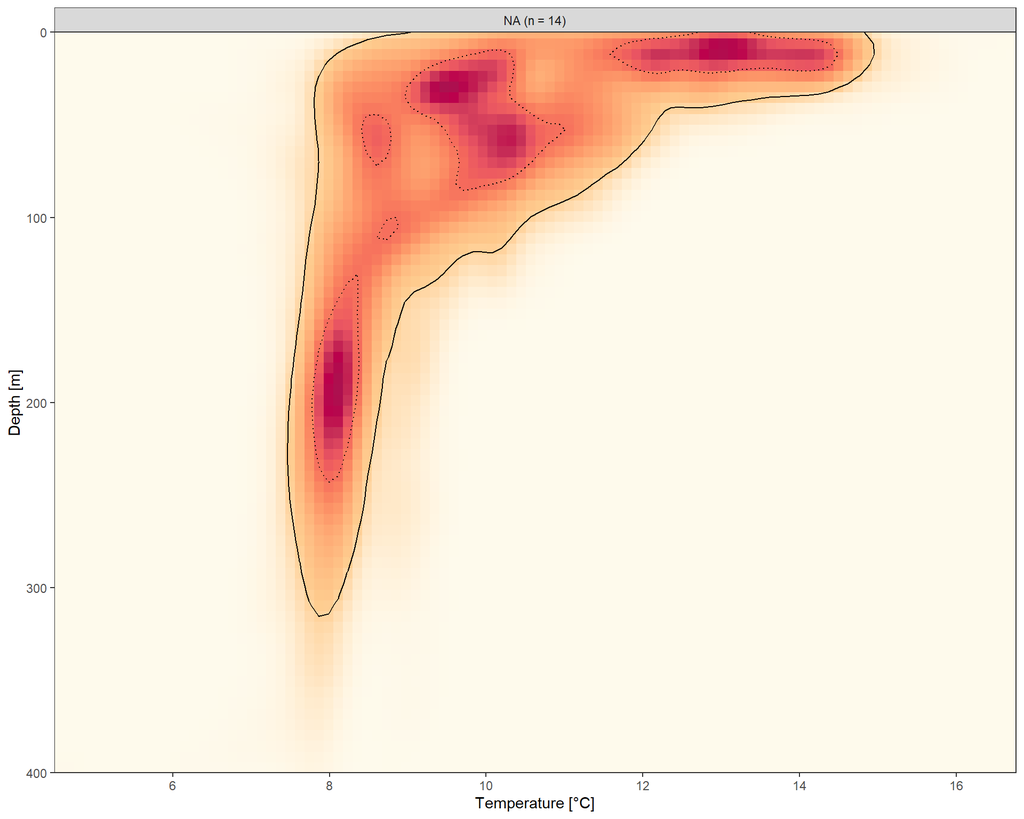

```r
H2_m <- H2 %>%
  group_by(Month, Depth) %>%
  reframe(Temp_mean = mean(Temp),
          Temp_sd = sd(Temp),
          Temp_se = sd(Temp)/(sqrt(n())))

hdata <- hdata %>% mutate(Month = factor(lubridate::month(Date, label = T, abbr = F),
                            levels = c("November","December","January","February","March",
                                       "April","May","June", "July","August","September","October")))
p1 <- ggplot() +
  # add density raster
  stat_density2d(data = hdata, aes(y = Temp_median, x = Depth_median, fill = after_stat(density)),
    alpha = 1,
    geom = "raster",
    contour = F) +
  geom_line(data = H2_m,aes(x = Depth, y = Temp_mean),alpha = 0.8,colour = "steelblue3")+
  geom_ribbon(data = H2_m, aes(x = Depth, y = Temp_mean, ymin = Temp_mean- Temp_se, ymax = Temp_mean + Temp_se),
              alpha = 0.25,fill= "steelblue3") +
  # 50% contour line
  geom_density2d(data = hdata, aes(y = Temp_median, x = Depth_median),
    contour_var = "density",alpha = 1,colour = "black", lty = "dotted",
    breaks = density_quantiles(hdata$Temp_median, hdata$Depth_median, c(0.5))) +

  # 95% contour line
  geom_density2d(data = hdata, aes(y = Temp_median, x = Depth_median),
    contour_var = "density",alpha = 1,colour = "black", lty = "solid",
    breaks = density_quantiles(hdata$Temp_median, hdata$Depth_median, c(0.95))) +
  scale_x_reverse(expand = c(0,0))+
  scale_y_continuous(expand = c(0,0), breaks =seq(6,18,2), labels =seq(6,18,2))+
  scale_fill_gradientn("density", colors = c("#fefaecff","#FECC8FFF","#FEB37BFF", "#FD9A6AFF",
                                              "#FA815FFF","#F4685CFF","#E85362FF",
                                              "#c83158ff","#bc004cff","#ab114fff"),
                        guide = guide_colorbar(frame.colour = "black", ticks.colour = "black", vjust = 1.5),
                        breaks = c(0.02,0.04,0.06), labels = c(0.02,0.04,0.06))+
  facet_wrap(~Month, labeller = stickylabeller::label_glue('{Month} (n = {n$n})'), nrow = 4)+
  labs(x = "Depth [m]", y = "Temperature [\u00B0C]")+
  coord_flip(xlim = c(400,0))+
  theme_bw()+
  theme(legend.position = "bottom",
        legend.box = "horizontal",legend.direction = "horizontal")

ggsave(plot = p1, filename = "plots/spurdog/supplement/fig6_DTniche_bymonth_wH2.png", width = 20, height = 28, units = "cm")
p1
```

# 5 Periodicity in depth use

## 5.1 Global periodogramme

Similar to a fast fourier transformation the wavelet power can be averaged across time to obtain the overall or ‘global’ power spectrum across the tracking time series.

Figure 3C: Global, scale-averaged periodogram indicating the overall wavelet power for each shark averaged for the entire deployment period. Only significant (p ≤0.05) powers are shown without transparency.

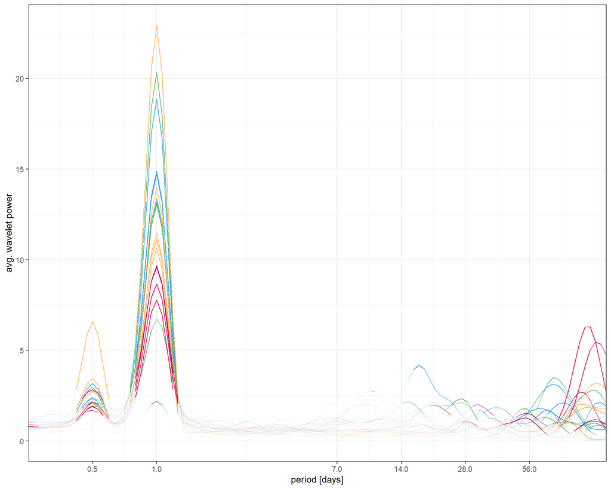

```r
ggplot(data = wtavg %>% mutate(sigcol = factor(case_when(pw_avg_sig > 0.05 ~ ">0.05",
                                                  pw_avg_sig > 0.01 & pw_avg_sig <= 0.05 ~ ">0.01,<=0.5",
                                                  pw_avg_sig <= 0.01  ~ "<=0.01"), levels= c(">0.05", ">0.01,<=0.5","<=0.01")),
                                 cohort = case_when(
    tagID %in% c("17P0023", "17P0749", "17P0796", "17P0864", "17P0866") ~ "2019",
    tagID %in% c("20P2042", "20P2044", "20P2045", "20P2046", "20P2047") ~ "2020",
    tagID %in% c("20P2660", "21P0036", "21P0037", "21P0038", "21P0039") ~ "2021",
    tagID %in% c("21P2088", "21P2202", "21P2203", "21P2209") ~ "2022")))+
  geom_line(aes(x = period, y = pw_avg, group = tagID, col = cohort , alpha = sigcol))+
  scale_x_continuous(trans="log2", breaks = c(0.5,1,7,14,28,56), expand = c(0,0))+
  scale_colour_manual("p-value", values = c("#34a2e5ff","#5fb667ff", "#feb55dff","#cd0e5bff"))+
  labs(x = "period [days]", y ="avg. wavelet power")+
  theme_bw()+
  theme(legend.position = "none")
```

```r
ggsave(filename = paste0("plots/spurdog/paper/fig3_avgwaveletpower.png"), width = 18, height = 10, units = "cm")
```

```r
wtavg %>% filter(period == 0.5 & pw_avg_sig <=0.05) %>% nrow()
```

```
#> [1] 17
```

```r
wtavg %>% filter(period == 1 & pw_avg_sig <=0.05) %>% nrow()
```

```
#> [1] 19
```

```r
wtavg %>% filter(period > 13 & period < 15 & pw_avg_sig <=0.05) %>% nrow()
```

```
#> [1] 1
```

```r
wtavg %>% filter(period > 26 & period < 30 & pw_avg_sig <=0.05) %>% nrow()
```

```
#> [1] 6
```

```r
t <- wtavg %>% filter(period > 84 & pw_avg_sig <=0.05)
length(unique(t$tagID))
```

```
#> [1] 16
```

```r
tags[which(! tags %in% unique(t$tagID))] # tags which have no sig period above 84 d
```

```
#> [1] "17P0866" "20P2045" "20P2660"
```

## 5.2 Simmulations

To test the effect of a deviation from a sine-signal in the depth time series (e.g. due to rapid descents and ascents or different light-induced dive regimes) on the power distribution of the continuous wavelet analysis, we perform a wavelet analysis on a simulated strict diel vertical pattern for 180 days switching from 80 to 200 m depth in a 12:12, 6:18 and 3:21 h rhythm. The 12:12h pattern represents conditions during equinox while 3:21 corresponds to a light regime during solstice in the study region.

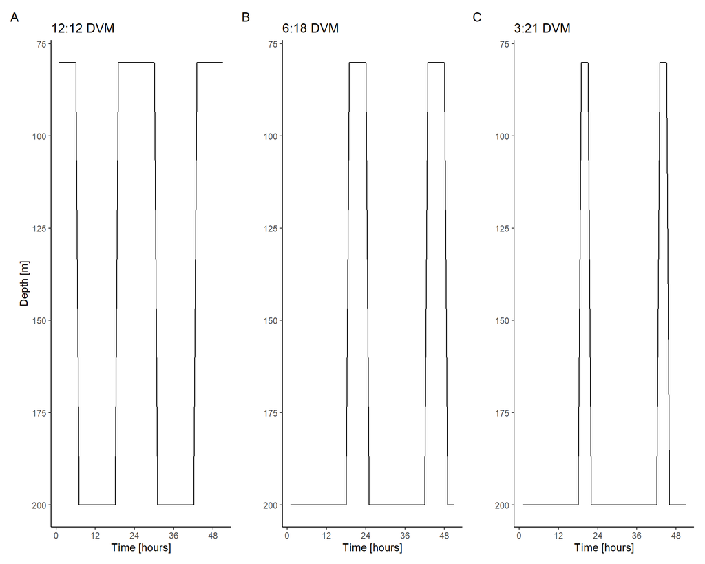

```r
# Synthethic timeseries mimicing DVM
depth1 <- rep(c(rep(80,12), rep(200,12)),180)
depth2 <- rep(c(rep(80,6), rep(200,18)),180)
depth3 <- rep(c(rep(80,3), rep(200,21)),180)

p1 <- ggplot(data = tibble(d = depth1[7:57], t = 1:51))+
  geom_line(aes(x = t, y= d))+
  scale_x_continuous(breaks = c(0,12,24,36,48))+
  scale_y_reverse()+
  theme_classic()+
  labs(x= "Time [hours]",y = "Depth [m]", title = "12:12 DVM")

p2 <- ggplot(data = tibble(d = depth2[7:57], t = 1:51))+
  geom_line(aes(x = t, y= d))+
  scale_y_reverse()+
  scale_x_continuous(breaks = c(0,12,24,36,48))+
  theme_classic()+
  labs(x= "Time [hours]",y = "", title = "6:18 DVM")

p3 <- ggplot(data = tibble(d = depth3[7:57], t = 1:51))+
  geom_line(aes(x = t, y= d))+
  scale_x_continuous(breaks = c(0,12,24,36,48))+
  scale_y_reverse()+
  theme_classic()+
  labs(x= "Time [hours]",y = "", title = "3:21 DVM")

p <- (p1|p2|p3)+ plot_annotation(tag_levels = 'A')
ggsave(filename = paste0("plots/spurdog/supplement/fig19_SyntheticTS_12-12_6-18h_3-21h.png"), width = 25, height = 8, units = "cm")
p
```

```r
# scalograms
datetime <- hdata %>% filter(sharkID == 15) %>% pull(DateTime)
df1 <- bind_cols(depth = depth1, date = datetime[1:length(depth1)])
df2 <- bind_cols(depth = depth2, date = datetime[1:length(depth2)])
df3 <- bind_cols(depth = depth3, date = datetime[1:length(depth3)])

wt1 <- WaveletComp::analyze.wavelet(my.data = df1,
                                    my.series = "depth",
                                    loess.span = 0, # no detrending
                                    dt = 1/24, # every hour
                                    dj = 1/24, #  "resolution" (no of suboctaves) - should correspond with col n.levels
                                    lowerPeriod = 1/4, # 6 h,
                                    upperPeriod = 2^7, # 128 d
                                    method = "AR",
                                    params = list(p = 0.5),
                                    n.sim = 100)
```

```
#> Starting wavelet transformation...
#> ... and simulations...
#>
```